# S02: NES concordance, HR against LR

The figure puts HR and LR on one pair of axes, once for training and once for the acute bout. Each point is a gene set: its x is the set’s NES in one arm, its y the NES in the other. NES is the normalised enrichment score from fgsea (fast gene set enrichment analysis): its sign says which way the set’s proteins moved, its size how strongly. fgsea scores each set once per contrast, so one arm’s NES against the other’s compares the arms set by set. There is no new test; the figure reshapes `03_Set_Contrasts` output.

Each pair gets two pages: all collections, then Hallmark and GO Slim alone. Four pages in total go to `b_reports/s02_nes_scatter.pdf`, and the numbers to `c_data/s02_nes_scatter.xlsx`.

## Packages

`analysis_reporting_helpers.R` supplies `write_workbook()`.

```r
library(here)
library(dplyr)
library(tidyr)
library(tibble)
library(purrr)
library(ggplot2)
library(patchwork)
source(here("00_Setup", "Shared_functions", "analysis_reporting_helpers.R"))
```

The one input is the set test table from `03_Set_Contrasts`. The chunk creates the output folders, stops if the input is missing and reads it.

```r
stage <- here("05_Figures", "HRvLR", "S02_NES_Scatter")
figure_dir <- file.path(stage, "b_reports")
out <- file.path(stage, "c_data")
walk(c(figure_dir, out), dir.create, recursive = TRUE, showWarnings = FALSE)

inputs <- c(set_tests = "03_Group_comparisons/HRvLR/03_Set_Contrasts/c_data/set_tests.rds")
paths <- map_chr(inputs, here)
if (!all(file.exists(paths))) {
  stop("Run 03_Set_Contrasts first. Missing: ", inputs[["set_tests"]])
}
fg <- readRDS(paths[["set_tests"]])
```

## One pair of contrasts

`run_pair()` takes two contrast names and a tag, and returns a concordance summary, an export table and two composite figures. Inside it:

- `paired` holds one row per set scored in both contrasts, with both NES and both FDR (BH within contrast). A set is significant in an arm at FDR < 0.05. It is discordant when its NES has opposite signs in the two arms, and a collapse survivor when either arm flags it `main`.
- `concordance()` gives the Spearman rho of x NES against y NES, its 95% CI by the Fisher z transform (`DescTools::CorCI()`), and the significant and discordant counts.
- `nes_panel()` draws one scatter. The dashed line is identity; grey points are significant in neither arm.
- `composite_all` is every collection, the collapse survivors, and the discordant sets on their own axes.
- `composite_curated` is Hallmark and GO Slim, the two collections whose members do not nest, then each concordant quadrant scaled to its own points so every set can be named.

```r
run_pair <- function(x_contrast, y_contrast, tag) {
  paired <- fg$set_tests |>
    filter(method == "fgsea", contrast %in% c(x_contrast, y_contrast)) |>
    mutate(contrast = if_else(contrast == x_contrast, "x", "y")) |>
    pivot_wider(
      id_cols = c(set_id, collection, pathway),
      names_from = contrast, values_from = c(n_proteins, nes, fdr, main)
    ) |>
    mutate(
      n_proteins = n_proteins_x,
      significance = case_when(
        fdr_x < 0.05 & fdr_y < 0.05 ~ "Both",
        fdr_x < 0.05 ~ x_contrast,
        fdr_y < 0.05 ~ y_contrast,
        .default = "NS"
      ) |> factor(c("Both", x_contrast, y_contrast, "NS")),
      # Opposite signs in the two arms, whichever arm, if either, is significant.
      discordant = sign(nes_x) != sign(nes_y),
      survivor = main_x | main_y,
      label = enrichVolcano::ev_clean_label(pathway)
    )

  concordance <- function(data) {
    # A quadrant panel can hold one or two sets, too few for cor.test.
    test <- if (nrow(data) >= 3) {
      cor.test(data$nes_x, data$nes_y, method = "spearman", exact = FALSE)
    } else {
      list(estimate = NA_real_, p.value = NA_real_)
    }
    hits <- filter(data, significance != "NS")
    interval <- if (is.na(test$estimate)) {
      c(NA_real_, NA_real_)
    } else {
      unname(DescTools::CorCI(test$estimate, nrow(data))[2:3])
    }
    tibble(
      n_sets = nrow(data), n_significant = nrow(hits), n_discordant = sum(hits$discordant),
      rho = round(unname(test$estimate), 3),
      rho_lower = interval[1], rho_upper = interval[2],
      p = test$p.value,
      same_sign = round(mean(!hits$discordant), 3)
    )
  }

  set_colours <- set_names(
    c("#6A3D9A", "#D7301F", "#2B6CB0"), c("Both", x_contrast, y_contrast)
  )

  # One panel builder for all six panels. labelled is the subset that gets names, so a dense
  # cloud and a zoomed handful of sets differ only in what is passed in.
  nes_panel <- function(data, title, labelled = data[0, ], pad = 0.12) {
    span <- range(c(data$nes_x, data$nes_y))
    limit <- span + c(-1, 1) * diff(span) * pad
    shown <- filter(data, significance != "NS")
    stats <- concordance(data)
    caption <- sprintf(
      "%d set%s | %d significant%s | %d discordant", stats$n_sets,
      if (stats$n_sets == 1) "" else "s", stats$n_significant,
      if (stats$n_sets >= 30) sprintf(" | rho %.2f", stats$rho) else "", stats$n_discordant
    )
    ggplot(data, aes(nes_x, nes_y)) +
      geom_hline(yintercept = 0, colour = "grey85", linewidth = 0.3) +
      geom_vline(xintercept = 0, colour = "grey85", linewidth = 0.3) +
      geom_abline(slope = 1, linetype = "dashed", colour = "grey45", linewidth = 0.4) +
      geom_point(
        data = filter(data, significance == "NS"),
        colour = "grey82", size = 0.45, alpha = 0.3
      ) +
      geom_point(aes(colour = significance, size = n_proteins), data = shown, alpha = 0.85) +
      ggrepel::geom_text_repel(
        data = labelled, aes(label = label), size = 2.3, colour = "grey15",
        segment.colour = "grey60", segment.size = 0.25, min.segment.length = 0,
        max.overlaps = Inf, seed = 1, force = 6, lineheight = 0.85
      ) +
      scale_colour_manual(values = set_colours, name = "significant in", drop = FALSE) +
      scale_size_continuous(
        range = c(1, 4.5), name = "proteins",
        limits = range(paired$n_proteins), breaks = c(50, 150, 300)
      ) +
      coord_fixed(xlim = limit, ylim = limit) +
      labs(
        x = paste("NES,", x_contrast), y = paste("NES,", y_contrast),
        title = title, subtitle = caption
      ) +
      theme_minimal(base_size = 9) +
      theme(
        plot.title = element_text(face = "bold", size = 10),
        plot.subtitle = element_text(size = 7.5, colour = "grey30")
      )
  }

  page_labels <- function(title, subtitle, caption) {
    plot_annotation(
      title = title, subtitle = subtitle, caption = caption, tag_levels = "A",
      theme = theme(
        plot.title = element_text(face = "bold", size = 13),
        plot.subtitle = element_text(size = 8.5, colour = "grey30"),
        plot.caption = element_text(size = 7.5, colour = "grey45", hjust = 0)
      )
    )
  }

  # Composite one: every collection, then the sets that survived collapse, then the discordant
  # handful on their own axes.
  discordant_sets <- filter(paired, discordant, significance != "NS")
  survivors <- filter(paired, survivor)
  composite_all <- wrap_plots(
    nes_panel(paired, "All collections"),
    nes_panel(survivors, "Collapse survivors"),
    # Too few points for a size key, and patchwork will not merge guide sets that differ.
    nes_panel(discordant_sets, "Discordant", labelled = discordant_sets, pad = 0.35) +
      guides(colour = "none", size = "none"),
    nrow = 1
  ) +
    page_labels(
      paste0("NES concordance, all collections: ", x_contrast, " against ", y_contrast),
      sprintf("fgsea NES per contrast, %d sets, BH within contrast", nrow(paired)),
      paste(
        "One point per gene set, scored in both", tag, "contrasts. Dashed line is identity;",
        "grey points reach neither threshold. Discordant sets are significant in at least one",
        "arm and sit on opposite sides of zero. Panel C rescales them.",
        "Table: c_data/s02_nes_scatter.xlsx, nes_scatter."
      )
    ) +
    plot_layout(guides = "collect") &
    theme(legend.position = "bottom")

  # Composite two: the two collections whose members do not nest, then each concordant quadrant
  # scaled to its own points so every set can be named.
  curated <- filter(paired, collection %in% c("Hallmark", "GO_Slim"))
  quadrant <- function(direction) {
    rows <- filter(curated, significance != "NS", !discordant, (nes_x > 0) == direction)
    # Panel A carries the colour key; a quadrant missing a category would draw a second one.
    nes_panel(rows, if (direction) "Up in both" else "Down in both", labelled = rows, pad = 0.22) +
      guides(colour = "none")
  }
  composite_curated <- (
    nes_panel(
      curated, "Hallmark and GO Slim",
      labelled = slice_min(
        filter(curated, significance != "NS"), fdr_x + fdr_y,
        n = 8, with_ties = FALSE
      )
    ) | (quadrant(TRUE) / quadrant(FALSE))
  ) +
    page_labels(
      paste0("NES concordance, Hallmark and GO Slim: ", x_contrast, " against ", y_contrast),
      sprintf("fgsea NES per contrast, %d non-nesting sets, BH within contrast", nrow(curated)),
      paste(
        "Panel A is every Hallmark and GO Slim set; B and C rescale the significant sets with the",
        "same sign in both arms, so each can be named. Point size is protein count, colour the",
        "contrast a set reached FDR 0.05 in. Table: c_data/s02_nes_scatter.xlsx,",
        "nes_scatter."
      )
    ) +
    plot_layout(guides = "collect") &
    theme(legend.position = "bottom")

  summary_table <- bind_rows(
    mutate(concordance(paired), population = "all collections"),
    mutate(concordance(survivors), population = "collapse survivors"),
    mutate(concordance(curated), population = "Hallmark and GO Slim")
  ) |>
    relocate(population)
  export <- paired |>
    transmute(
      pair = tag, x_contrast, y_contrast, set_id, collection, pathway, label, n_proteins,
      nes_x = round(nes_x, 3), nes_y = round(nes_y, 3),
      fdr_x = signif(fdr_x, 4), fdr_y = signif(fdr_y, 4),
      significance = as.character(significance), discordant, survivor
    ) |>
    arrange(significance, desc(abs(nes_x) + abs(nes_y)))
  list(
    summary = mutate(summary_table, pair = tag, .before = 1), export = export,
    figures = list(composite_all, composite_curated)
  )
}
```

## Training and acute

Training pairs `Training_HR` with `Training_LR`; acute pairs `Acute_HR` with `Acute_LR`. The two pairs’ summaries and export rows are stacked into one table each.

```r
pairs <- list(
  run_pair("Training_HR", "Training_LR", "training"),
  run_pair("Acute_HR", "Acute_LR", "acute")
)
summary_table <- list_rbind(map(pairs, "summary"))
export <- list_rbind(map(pairs, "export"))
summary_table
```

```
# A tibble: 6 × 10
  pair    population n_sets n_significant n_discordant   rho rho_lower rho_upper
  <chr>   <chr>       <int>         <int>        <int> <dbl>     <dbl>     <dbl>
1 traini… all colle…   1378           198           36 0.372   0.326       0.417
2 traini… collapse …     54            54            8 0.584   0.374       0.736
3 traini… Hallmark …     91            19            6 0.158  -0.0491      0.353
4 acute   all colle…   1378           327          128 0.256   0.206       0.304
5 acute   collapse …    102           102           46 0.333   0.148       0.495
6 acute   Hallmark …     91            39           18 0.212   0.00624     0.400
# ℹ 2 more variables: p <dbl>, same_sign <dbl>
```

## Save

The PDF gets four pages, one per composite. The workbook holds the concordance summary and one row per set per pair.

```r
pdf(file.path(figure_dir, "s02_nes_scatter.pdf"), width = 11, height = 8.5)
walk(list_flatten(map(pairs, "figures")), print)
invisible(dev.off())
sheets <- list(
  concordance = summary_table,
  nes_scatter = export
)
holds <- c(
  "Spearman rho (Fisher-z 95% CI) of HR against LR NES, significant and discordant counts.",
  "One row per set scored in both arms: both NES, both FDR, significance and discordance."
)
write_workbook(sheets, holds, file.path(out, "s02_nes_scatter.xlsx"), inputs, paths)
```

## Figure

The same four pages, drawn again for this page, in PDF order: training all collections, training Hallmark and GO Slim, acute all collections, acute Hallmark and GO Slim.

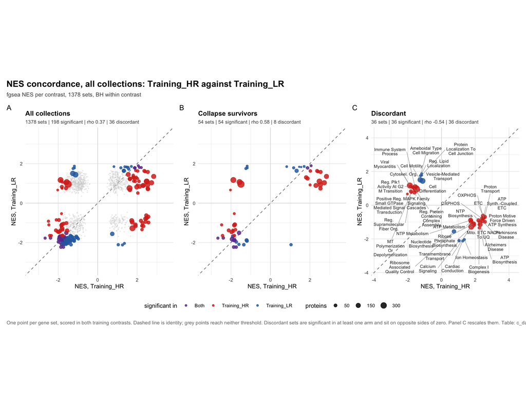

Figure 1: NES of HR against LR, training then acute.

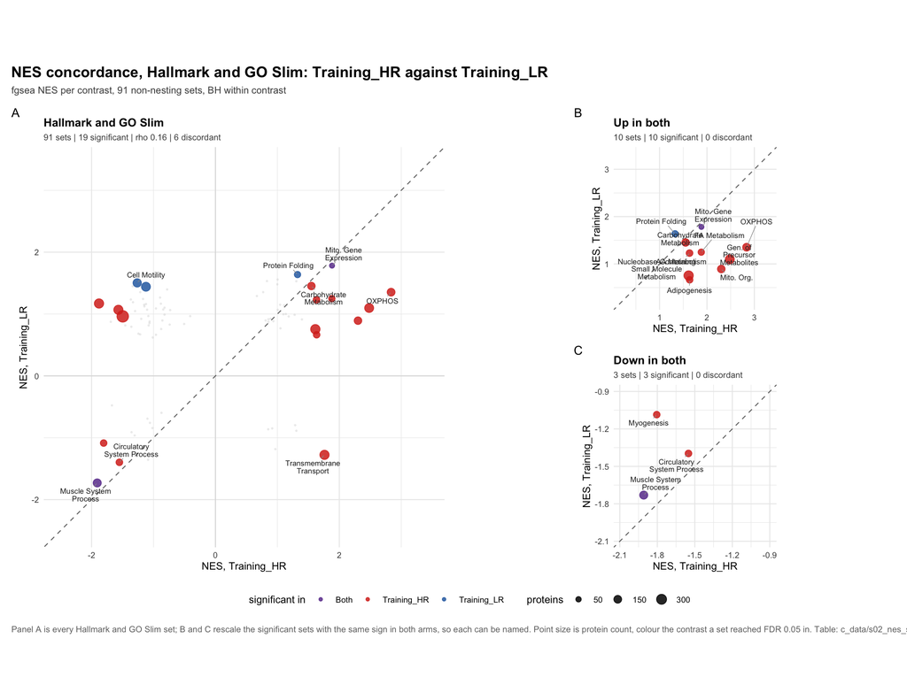

Figure 2: NES of HR against LR, training then acute.

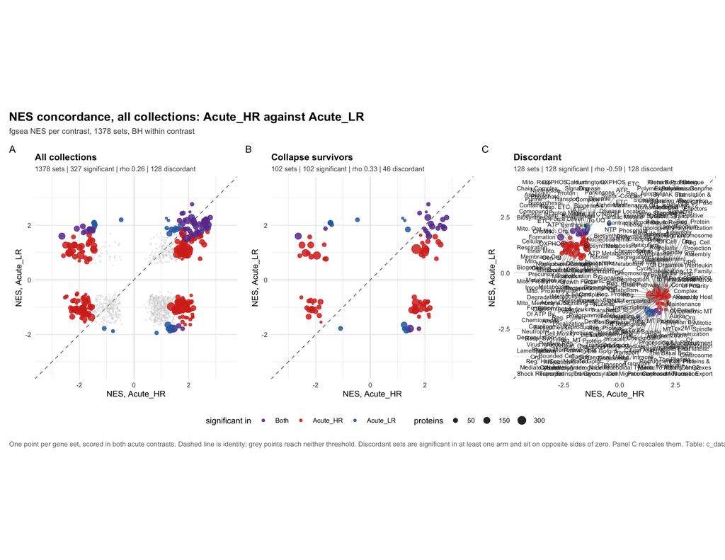

Figure 3: NES of HR against LR, training then acute.

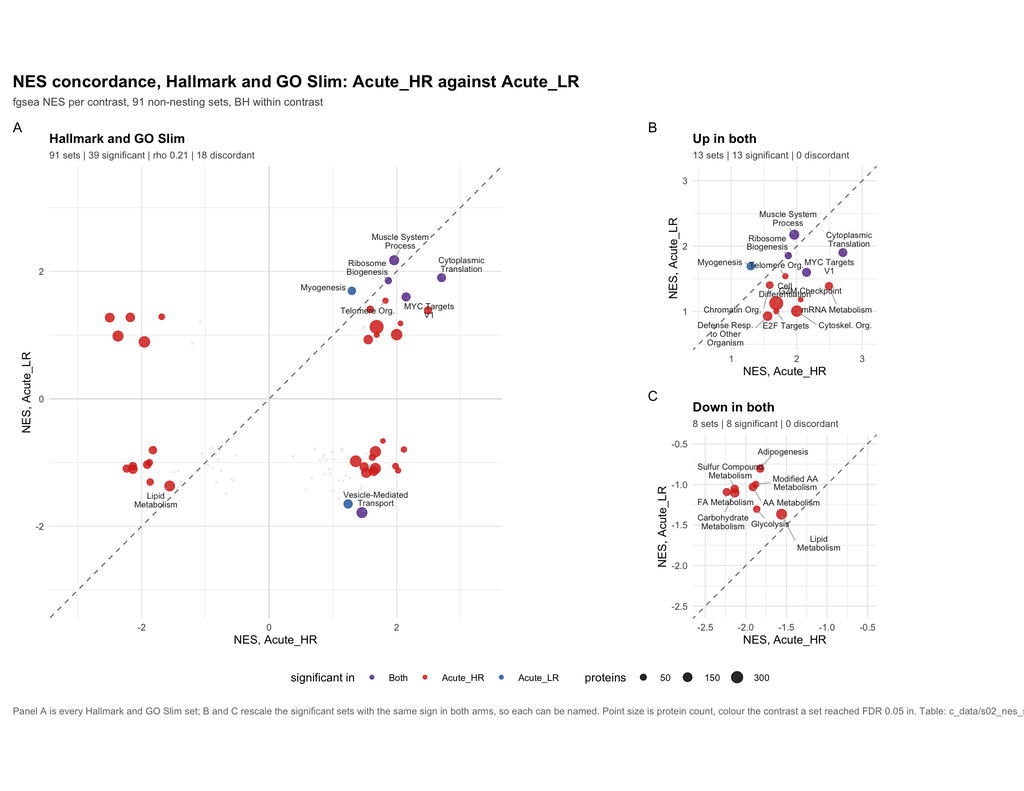

Figure 4: NES of HR against LR, training then acute.

```r
walk(list_flatten(map(pairs, "figures")), print)
```